# Project: Investigate a Dataset (TMBD- Movies Data Set!)

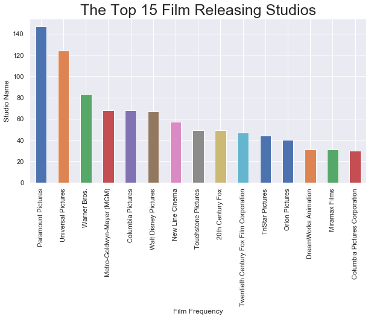

```python
# Movies Per Studio

studio_films = groupby_sum('title', 'production_companies').value_counts()

studio_films.iloc[:15].plot(kind = 'bar')

plt.title('The Top 15 Film Releasing Studios', fontsize = 25)
plt.xlabel('Film Frequency')
plt.ylabel('Studio Name');
```

### Parmaount again leads the top 15 studios in film production.

[output not shown]

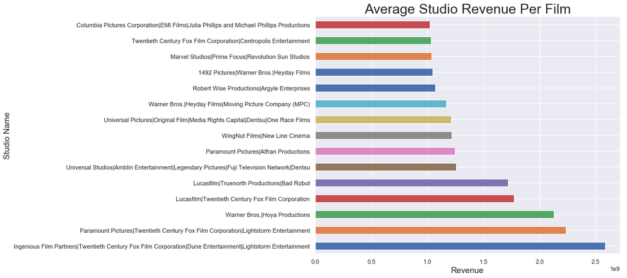

```python
# Average Studio Revenue per Film

studio_avg_per_film = dir_film_avg('production_companies', 'profit_adj', 'production_companies').sort_values(ascending = False)[:15]

studio_avg_per_film.plot(kind = 'barh', figsize = (10,8))

plt.title('Average Studio Revenue Per Film', fontsize = 25)
plt.xlabel('Revenue', fontsize = 15)
plt.ylabel('Studio Name', fontsize= 15)
```

## CONCLUSIONS:

The Movie making business is good. Film Releases and Profits have increased steadily since 1960.

Movie runtimes have normally decreased in length since 1960. The average movie length for the database is 103 minutes.

If you wanted to hire a director with a name people are familiar with...Woody Allen has made the most movies.

If you wanted to hire a director who has made the most profits...hire Stephen Speilberg.

If you wanted to hire a director who is both tops in profit and average profit per film....hire George Lucas.

## LIMITATIONS

The conclusions reached are dependent on the information within the data set. I have not verified the accuracy of the gathering/collection of information within the set.

The conclusions reached are not a guarantee of profits, likeability or positive word of mouth from viewers. Each film is a story with many names tied to it.

Further investigation is required to correlate movie attributes with profits. We would need to add back positivity scores and look for associations with award winners.

Please note that duplicate data was removed and may have altered the outcome of the findings.

Please note that movies with 0 run times were replaced with NAN values.

We can also dive into the months that typically result in the highest profits and film releases. Understanding these two characteristics can help a studio assess when to release their film.

We can also look into genres and determine how movie types are associated to profits and awards.